# SNA lab 4

Author

Alexandra Rottenkolber

Published

February 5, 2026

# 0 Content

0. From last week
- 0.1 Exercise section of last time
1. Ego networks
2. Graph models
- 2.1 Erdős–Rényi model
- 2.2 Watts–Strogatz model and its small world properties
- 2.3 Barabasi-Albert model, and preferential attachment

# 1 From last week

## 1.1 Comments on cohesive blocks

See solutions sheet from last week.

## 1.2 Exercise section of last time

See solutions sheet from last week.

# 2 Local- vs global level: Ego-networks

Another approach to explore the meso-level characteristics of a network is the study of ego networks. An ego network is a subgraph of the original network, whose boundaries are determined by whether or not a node is still connected to the ego (i.e. the node you decided to start with). For example, the ego network for node $i$ includes all the nodes of the original graph that are connected to $i$.

Ego networks can tell you something about a local neighborhood a node (person) lives in.

```r
# A friendship network
edges_dir <- c("Elizabeth", "Cindy",
               "George", "Cindy",
               "Cindy", "David",
               "David", "Betty",
               "Betty", "Adam",
               "Cindy", "Elizabeth",
               "Fred", "Betty",
               "Cindy", "Betty",
               "Adam", "Fred",
               "Adam", "David")

# Create a undirected graph
Gu <- graph_from_edgelist(matrix(edges_dir, ncol = 2, byrow = TRUE), directed = FALSE)

# Add some attributes
V(Gu)$gender <- c("f", "f", "m", "d", "f", "m", "m")
V(Gu)$gender_num <- c(1, 1, 2, 3, 1, 2, 2)
V(Gu)$age <- c(27, 25, 22, 17, 42, 51, 48)
```

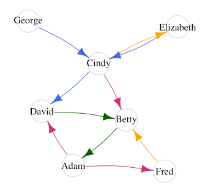

We can access an ego network the following way:

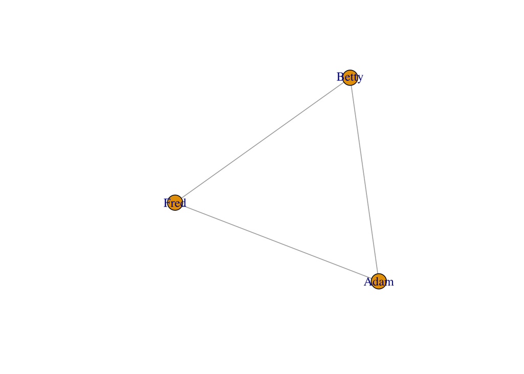

```r
# plot an ego graph for one node
plot(make_ego_graph(Gu, order = 1,  nodes = "Fred",  mode = c("all"),  mindist = 0)[[1]])
```

Let’s see how the average individuals experiences the gender distribution in their surrounding. Does the local level experience of individuals match the global level averages?

Let’s start at the local level: How do the gender shares in an individuals surrounding look like?

```r
# how does the average local experience look like?
egos <- V(Gu)$name

avg_f_gender = 0
avg_d_gender = 0
avg_m_gender = 0
for (n in egos) {
  ego_net <- make_ego_graph(Gu, order = 1,  nodes = n,  mode = c("all"),  mindist = 0)[[1]]
  ego_net_filtered <- delete_vertices(ego_net, n)

  if ("f" %in% V(ego_net_filtered)$gender) {
    avg_f_gender <- avg_f_gender + table(V(ego_net_filtered)$gender)[["f"]]/length(V(ego_net_filtered))
  }

  if ("d" %in% V(ego_net_filtered)$gender) {
    avg_d_gender <- avg_d_gender + table(V(ego_net_filtered)$gender)[["d"]]/length(V(ego_net_filtered))
  }

  if ("m" %in% V(ego_net_filtered)$gender) {
    avg_m_gender <- avg_m_gender + table(V(ego_net_filtered)$gender)[["m"]]/length(V(ego_net_filtered))
  }
}

cat("The average person thinks that",
    round(100 * avg_f_gender / length(V(Gu))), "% of the network is female,",
    round(100 * avg_d_gender / length(V(Gu))), "% divers, and",
    round(100 * avg_m_gender / length(V(Gu))), "% male.")
```

```
The average person thinks that 61 % of the network is female, 12 % divers, and 27 % male.
```

And what are the averages at the global level?

```r
# the global level
global_f_gender = table(V(Gu)$gender)[["m"]]/length(V(Gu))
global_d_gender = table(V(Gu)$gender)[["d"]]/length(V(Gu))
global_m_gender = table(V(Gu)$gender)[["f"]]/length(V(Gu))

cat("The average person thinks that",
    round(100 * global_f_gender), "% of the network is female,",
    round(100 * global_d_gender), "% divers, and",
    round(100 * global_m_gender), "% male.")
```

```
The average person thinks that 43 % of the network is female, 14 % divers, and 43 % male.
```

What we observed here is called the majority illusion. Even if a majority of people is not female, we observe a network in which everybody individually thinks the opposite is true.

The majority illusion describes a phenomenon in which individuals overestimate the prevalence of some attribute, making it appear more popular than it is if they only consider their local neighbours in the network from an ego perspective. This illusion can be traced to the power of nodes with high centrality to skew the observations of many others. This is because such nodes are overrepresented in the local neighbourhoods of other nodes.

*Question to you:*

- Which implications does this phenomenon, in your opinion, have for social cohesion? Or the “public opinion”? Political influence? …?

*Your answer:*

- For example, the illusion can become problematic in political debates, in which people might feel that certain attributes or political opinions are more prevalent than they actually are because they are viewed at from the ego perspective, instead of a global network perspective.

_* Extra (for those interested): *_

- The majority illusion is only one peculiarity. Another stunning case, driven by homophily, that I want to bring to your attention is that even mild preferences often result in very strict homophilic patterns (along the lines of “the aggregate is more than the sum (of individual level preferences)”). One of the most famous example to illustrate this is residential segegation (see work of Nobel Prize-winning game theorist Thomas Schelling, and especially his paper [Dynamic models of segregation](https://www.stat.berkeley.edu/~aldous/157/Papers/Schelling_Seg_Models.pdf) from 1971). You can play an interactive version of the paper content here: [Parable of Polygons](https://ncase.me/polygons/). Even if people are happy being in the minority, the group ends up being segregated. Comment: There is no network in this interactive post, but one could easily transfer this to a friendhip network where people are allowed to rewire their connections.

# 3 Graph models

## 3.1 Erdős–Rényi model

The simplest version of a random graph is the Erdös-Rényi (ER) model, sometimes called the $G_{n,p}$ model. In the model, the number of nodes $n$ and the connection probability $p$ are pre-defined. Then, connections are formed at random based on the connection probabaility $p$.

As the mathematics of Erdös-Rényi graphs is relatively simple, they have been studied extensively. In some cases, they can serve as a null model to conduct statistical tests on networks (a model to compare your real-world network characeristics against). Often, however, ER-graphs a little too simplistic to provide appropriate comparisons for empirical networks. Therefore, more sophisticated models and techniques for statistical hypothesis testing have been developed, which will be covered later.

Let’s construct a random graph à la Erdős–Rényi ourselves. We can (1) start with an empty graph and add n nodes. Then, (2) write an algorithm that determines (based on our given probability) whether any two nodes will be connected by an edge or not.  
(3) include an option that lets us choose whether to generate a directed or undirected graph. (4) visualise our graph.

```r
# Function to generate an Erdős-Rényi graph
generate_erdos_renyi <- function(number_of_nodes, p, directed_graph = TRUE) {

  # make a graph with a certain number of nodes and set the type
  G <- make_empty_graph(n = number_of_nodes, directed = directed_graph)

  # Generate all possible edges
  if (directed_graph) {
    edges <- permutations(number_of_nodes, 2) # edgelist
  } else {
    edges <- combinations(number_of_nodes, 2) # edgelist
  }

  # Select a subset of all possible edges based on probability p
  selected_edges <- edges[sample(1:nrow(edges), round(nrow(edges) * p), replace = FALSE), ]

  # add the subset of edges
  if (nrow(selected_edges) > 0) {
    G <- add_edges(G, c(t(selected_edges)))
  }

  return(G)
}

# NOTE: There is also an igraph function, that you can use: igraph::erdos.renyi.game()
```

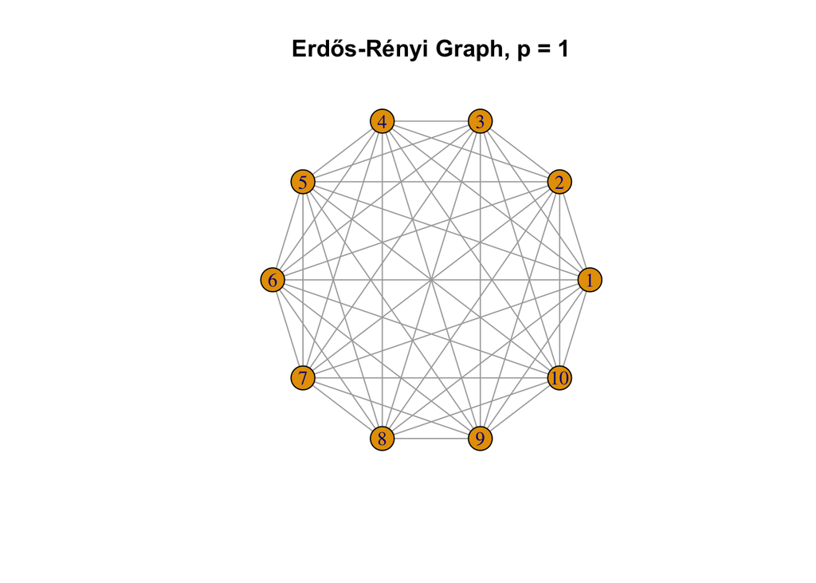

```r
# Generate a fully connected graph
set.seed(123)  # For reproducibility
p = 1
number_of_nodes = 10
G <- generate_erdos_renyi(number_of_nodes = number_of_nodes, p = p, directed_graph = FALSE)

# Plot the graph with circular layout
plot(G, layout = layout_in_circle(G), vertex.label = V(G)$name, main = paste0("Erdős-Rényi Graph, p = ", p))
```

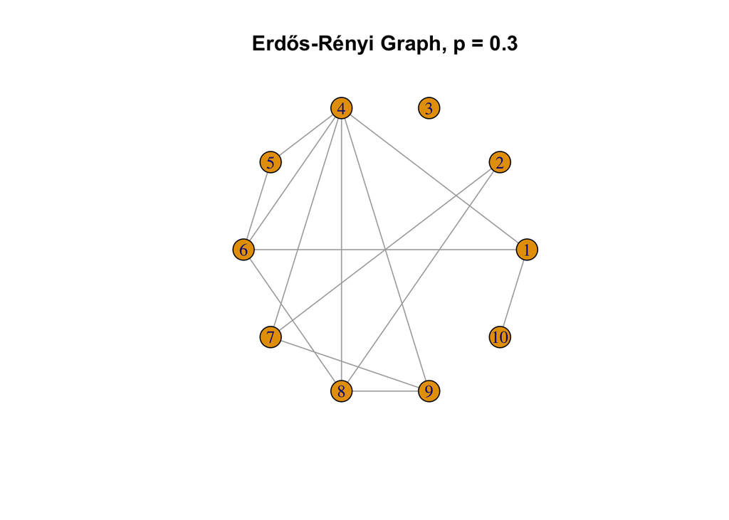

```r
# Generate a less connected graph
set.seed(123)  # For reproducibility
p = 0.3
G <- generate_erdos_renyi(number_of_nodes = number_of_nodes, p = p, directed_graph = FALSE)

# Plot the graph with circular layout
plot(G, layout = layout_in_circle(G), vertex.label = V(G)$name, main = paste0("Erdős-Rényi Graph, p = ", p))
```

This nodes are completely randomly connected. Only 30% of all possible edges are present.

Erdős–Rényi networks are a good starting point in building random graphs. A surprisingly realistic feature of them is the short average path length. In contrast to real-world networks, however, ER-graphs are characterized by a low clustering coefficient. To overcome such shortcomings, more sophisticated random graph models have been developed. The two most famous examples are the Watts-Strogatz and the Barabási-Albert model.

Both types of networks aim to provide a simple mathematical model that result in more realistic features than ER-graphs. While the Watts-Strogatz model focuses on the observation that many networks show a ‘small-world’ effect, the Barabási-Albert model proposes a preferential link attachment mechanism to create a graph with a scale-free (i.e. power-law) degree distribution.

There are plenty of other models in the literature, which aim to generate more realistic network properties (i.e. capture “what we would expect to see”). Among one the most prominent ones is the ‘configuration model’, which is a versatile model to produce graphs with any form of degree distribution. For more details, see for example Newman (2018) Chapter 12 and Latora et al. (2018) Chapter 5.

In the following exercises, we focus on the Watts-Strogatz model and the Barabási-Albert model.

## 3.2 Watts–Strogatz model and its small-world properties

The idea of the Watts-Strogatz model construction is the following: We first create a ring of n nodes (*size* parameter for igraph). Then each node in the ring is being connected to its k nearest neighbors (k-1 neighbors if k is odd) (*nei* parameter in igraph). In the next step, we introduce some shortcuts by replacing some edges as follows: We replace every edge u-v in the underlying “n-ring with k nearest neighbors” with probability p with an edge u-w, while w is selected randomly. The random reviewing keeps the number of edges stable.

Paper for reference: Duncan J. Watts and Steven H. Strogatz (1998): Collective dynamics of small-world networks, Nature, 393, pp. 440–442

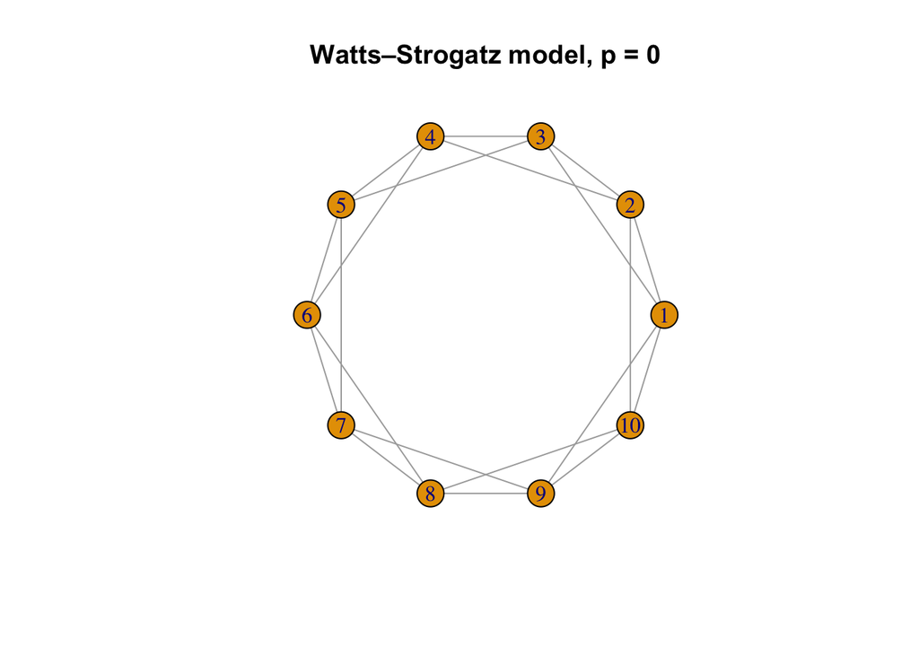

```r
set.seed(123)
p = 0
k = 2
G_ws <- sample_smallworld(dim = 1, size = number_of_nodes, nei = k, p = p, loops = FALSE, multiple = FALSE)

# Plot the graph with circular layout
plot(G_ws, layout = layout_in_circle(G_ws), vertex.label = V(G_ws)$name, main = paste0("Watts–Strogatz model, p = ", p))
```

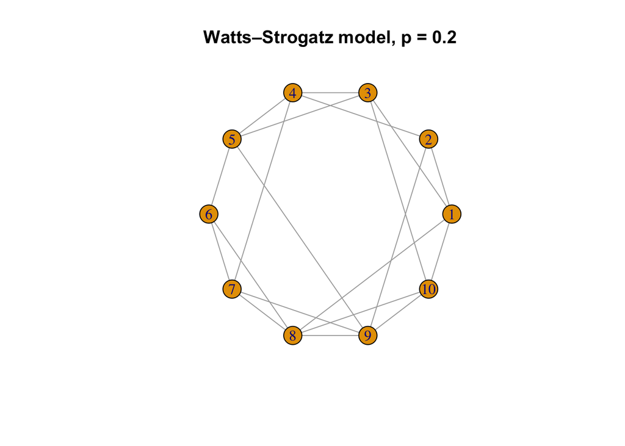

```r
p = 0.2
G_ws <- sample_smallworld(dim = 1, size = 10, nei = 2, p = p, loops = FALSE, multiple = FALSE)

# Plot the graph with circular layout
plot(G_ws, layout = layout_in_circle(G_ws), vertex.label = V(G_ws)$name, main = paste0("Watts–Strogatz model, p = ", p))
```

## 3.3 Barabási–Albert model, and preferential attachment

The last model, which we will cover in this lab, is the Barabási–Albert model. Here, a graph of n nodes is grown by subsequentially attaching new nodes to the network until the desired number of nodes is reached. New incoming nodes thereby have a pre-specified number of edges m with which they can attached themselves to already existing nodes. New incoming nodes attached themselves preferentially existing nodes with high degree.

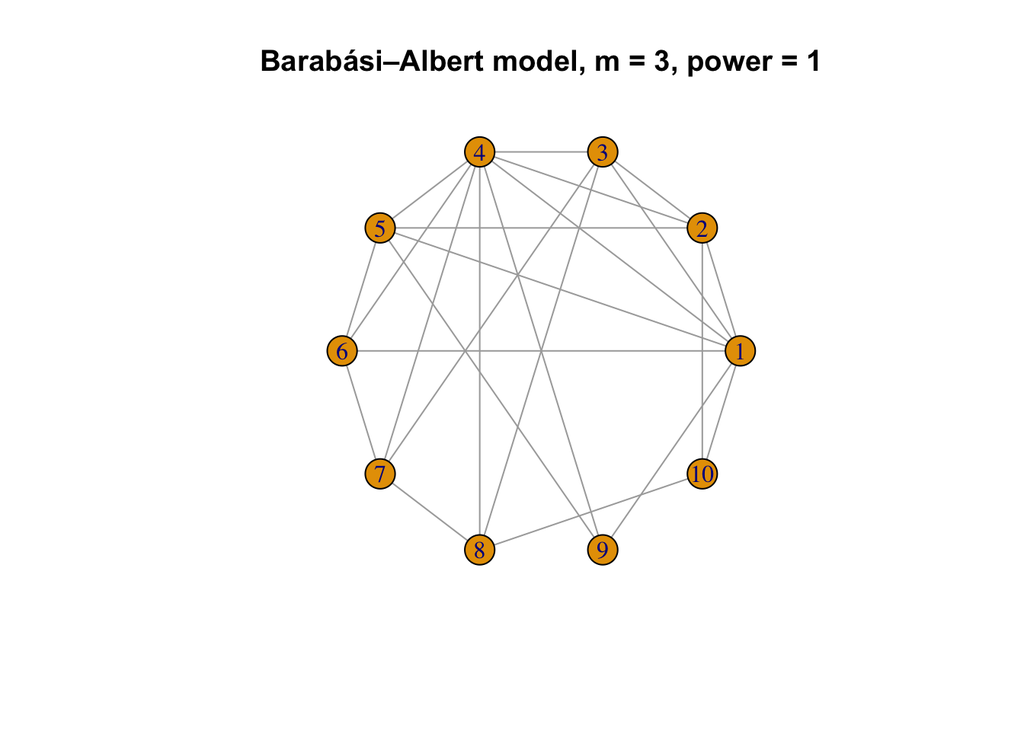

```r
set.seed(123)
m = 3
power = 1 # "attractiveness of nodes with higher degree"
G_pa <- sample_pa(number_of_nodes, power = power, m = m, directed = FALSE)

# Plot the graph with circular layout
plot(G_pa, layout = layout_in_circle(G_pa), vertex.label = V(G_pa)$name, main = paste0("Barabási–Albert model, m = ", m, ", power = ", power))
```

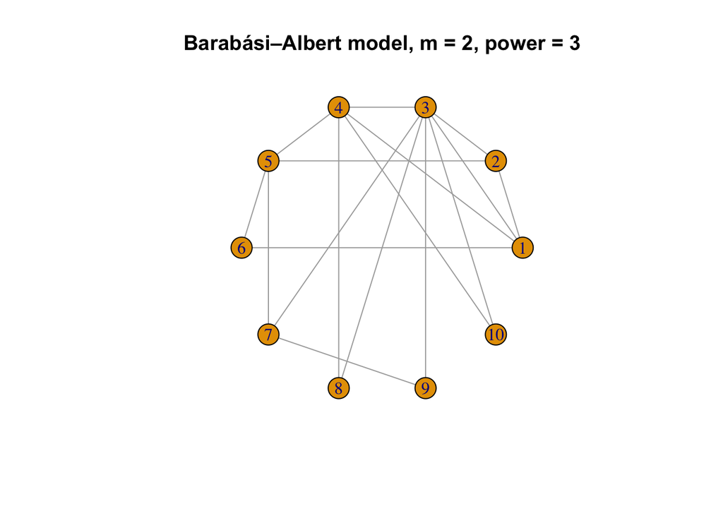

```r
set.seed(123)
m = 2
power = 3 # "attractiveness of nodes with higher degree"
G_pa <- sample_pa(number_of_nodes, power = power, m = m, directed = FALSE)

# Plot the graph with circular layout
plot(G_pa, layout = layout_in_circle(G_pa), vertex.label = V(G_pa)$name, main = paste0("Barabási–Albert model, m = ", m, ", power = ", power))
```

# 4 Exercises

## 4.1 Exercise 1

Now, we will start comparing a “real-world” dataset with some of the random graph models that were introduced in this week’s lecture. The dataset contains the citation network of DBLP – a database of different scientific publications ([source](https://networkrepository.com/cit-DBLP.php)).

1. Generate an Erdős-Rényi graph, a Watts-Strogatz model, and a Barabási–Albert model with (approximately) the same number of nodes and edges as observed in the citation network.

For all four networks,

2. Plot the probability distribution (PDF) of finding a node with a certain degree over the degrees, and
3. Plot the complement of a cumulative distribution (CCDF) in log-log scale.

The CCDF displays basically the same information as the probability distribution over degrees, but instead of having the ‘probability of finding a node with its degree equal to k’ on the y-axis, the CCDF shows the ‘probability of finding a node of degree k or higher’. The CCDF is not a scattergram/histogram anymore, but a function that comes in handy if you want to fit it. Discuss the salient differences between the observed distributions for PDF and CCDF.

4. Compare and interpret.

```r
# read in citation network
edges_df <- read.csv("./data/cit-DBLP.edges", skip = 2, header = FALSE, sep = " ") # edgelist
edges_df$V3 <- NULL
mtx <- as.matrix(edges_df)
G_cit <- graph_from_edgelist(mtx, directed = FALSE)
G_cit$name <- "cit-DBLP"

number_of_nodes = length(V(G_cit))
number_of_edges = length(E(G_cit))
density = edge_density(G_cit)
```

```r
# create ER graph with same number of nodes / edges
G_er <- erdos.renyi.game(n = number_of_nodes, p.or.m = density, directed = FALSE)
G_er$name <- "Erdős-Rényi graph"

# create WS graph with same number of nodes / edges
k = 4
p = 0.3
G_ws <- sample_smallworld(dim = 1, size = number_of_nodes, nei = k, p = p)
G_ws$name <- "Watts-Strogatz"

# create BA graph with same number of nodes / edges
m = 4
G_pa <- sample_pa(n = number_of_nodes, m = m, directed = FALSE)
G_pa$name <- "Barabási–Albert"

# compare characteristics
print_info <- function(grph){
  cat("\nNumber of nodes: \t ", length(V(grph)))
  cat("\nNumber of edges: \t ", length(E(grph)))
  cat("\nis directed?: \t\t ", is_directed(grph))
  cat("\nDensity: \t\t ", round(edge_density(grph), 5), "\n")
}

print_info(G_cit)
```

```
Number of nodes:      12591
Number of edges:      49743
is directed?:         FALSE
Density:          0.00063
```

```r
print_info(G_er)
```

```
Number of nodes:      12591
Number of edges:      49590
is directed?:         FALSE
Density:          0.00063
```

```r
print_info(G_ws)
```

```
Number of nodes:      12591
Number of edges:      50364
is directed?:         FALSE
Density:          0.00064
```

```r
print_info(G_pa)
```

```
Number of nodes:      12591
Number of edges:      50354
is directed?:         FALSE
Density:          0.00064
```

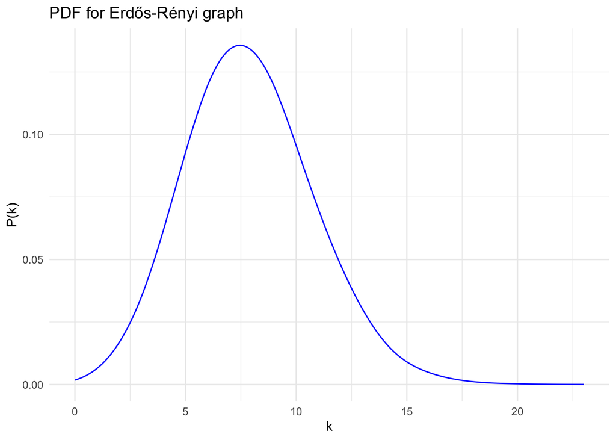

```r
# Function to plot the probability density function (PDF) of node degrees
plot_PDF <- function(G) {
  degrees <- degree(G)  # Get degrees of nodes
  df <- data.frame(degree = degrees) # store in datafame

  ggplot(df, aes(x=degree)) +
    geom_density(color = "blue", alpha = 0.3, bw = 1) +
    labs(title = paste("PDF for", ifelse(is.null(G$name), "Graph", G$name)),
         x = "k",
         y = "P(k)") +
    theme_minimal()
}

plot_PDF(G_er)
```

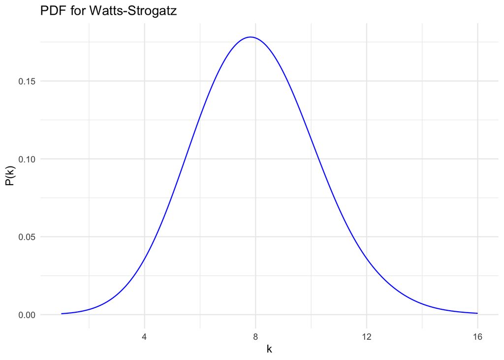

```r
plot_PDF(G_ws)
```

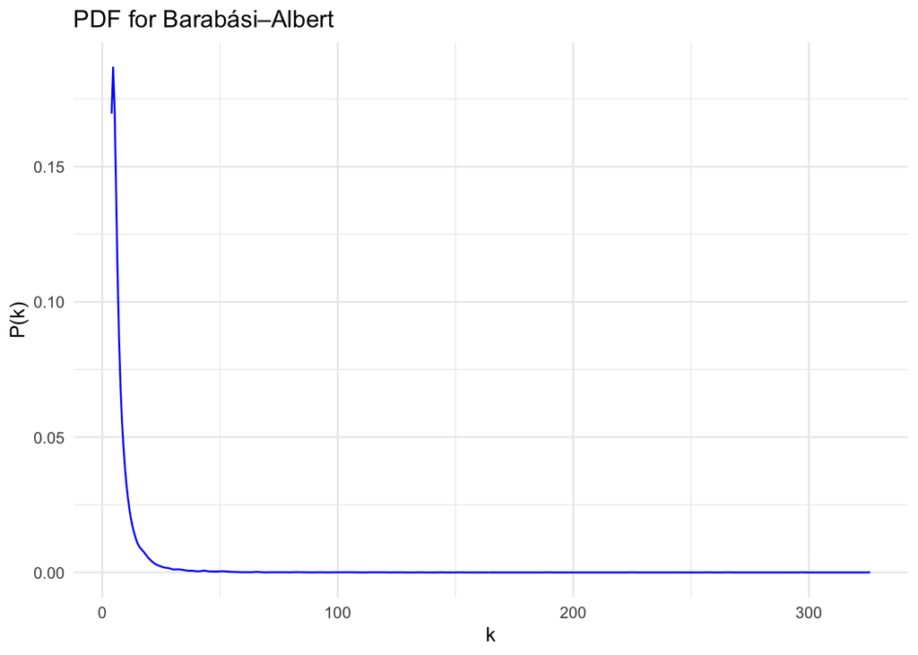

```r
plot_PDF(G_pa)
```

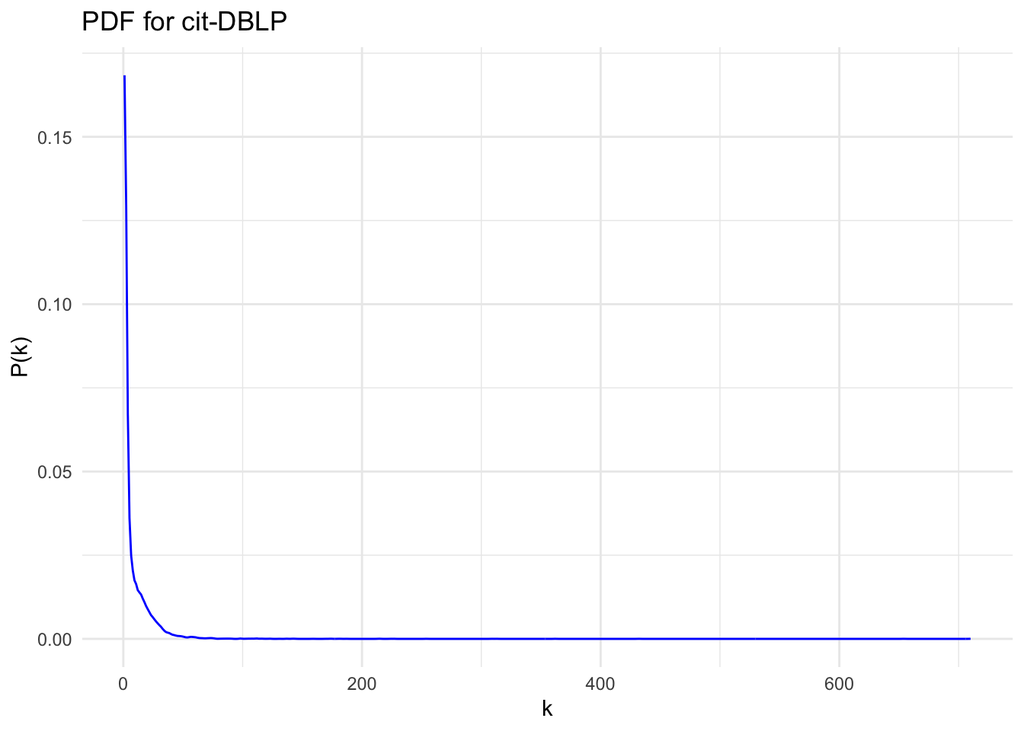

```r
plot_PDF(G_cit)
```

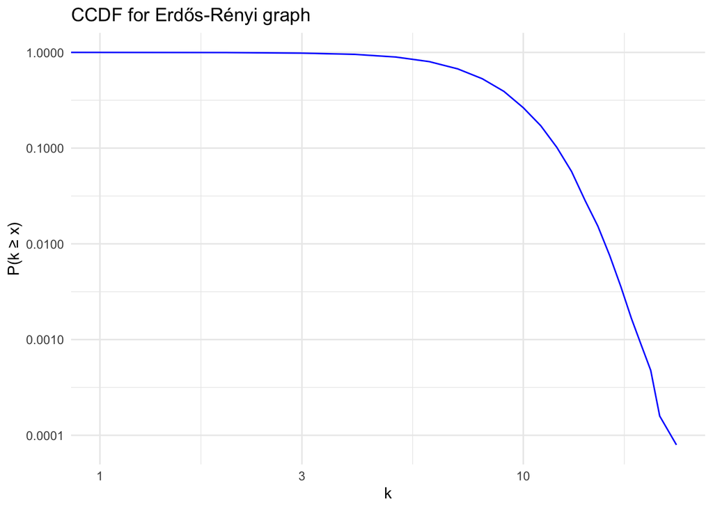

```r
# Function to plot the Complementary Cumulative Distribution Function (CCDF)
plot_CCDF <- function(G) {
  degrees <- degree(G)  # Get degrees of nodes
  unique_vals <- sort(unique(degrees))  # sort the degrees by size
  n <- length(V(G))  # Total number of nodes

  # sum of how many nodes have a degree larger than k, apply value by value
  ccdf <- sapply(unique_vals, function(k) sum(c(degrees >= k)) / n)

  # make data frame for plotting
  df <- data.frame(degree = unique_vals, ccdf = ccdf)

  # plotting
  ggplot(df, aes(x = degree, y = ccdf)) +
    geom_line(color = "blue") +
    scale_x_log10() +  # Log scale for x-axis
    scale_y_log10() +  # Log scale for y-axis
    labs(title = paste("CCDF for", ifelse(is.null(G$name), "Graph", G$name)),
         x = "k",
         y = "P(k ≥ x)") +
    theme_minimal()
}

plot_CCDF(G_er)
```

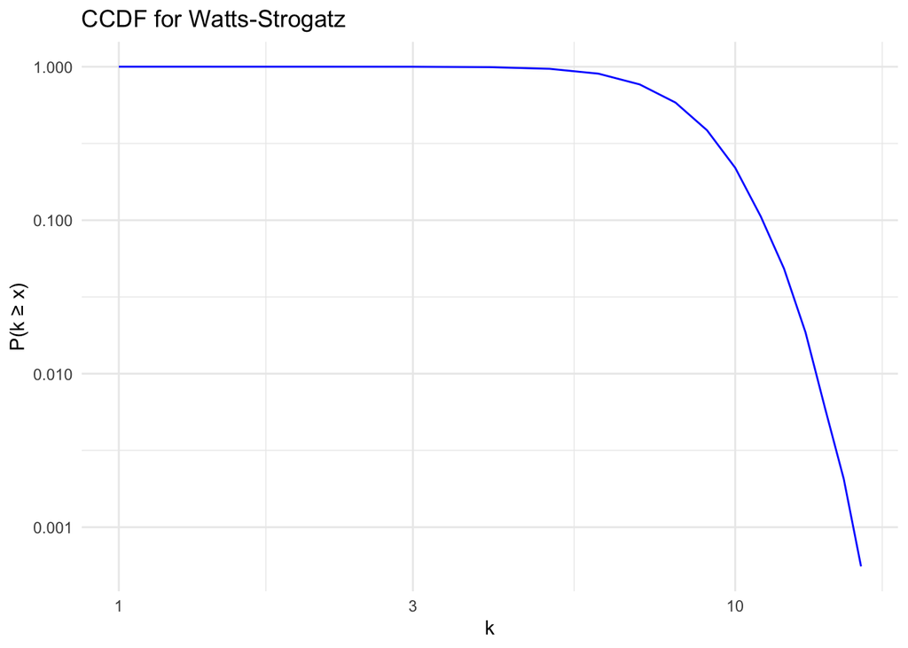

```r
plot_CCDF(G_ws)
```

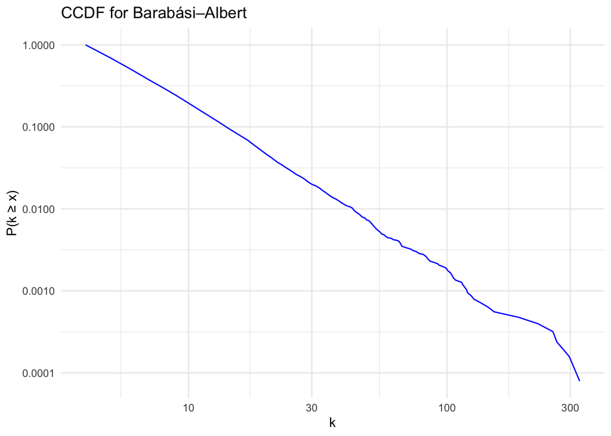

```r
plot_CCDF(G_pa)
```

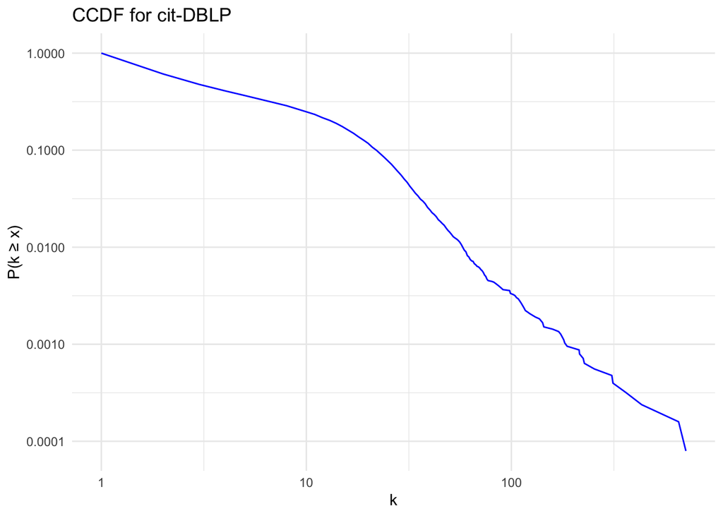

```r
plot_CCDF(G_cit)
```

The graphs show different PDFs and CCDFs. Both the simple Erdös-Rényi model and the Watts-Strogatz model lead to degree distributions that roughly follow a Poisson (or approximated normal) distribution. The PDF show the typical bell shape, while the low probability for observing very large values can be seen in the steep decay in the CCDFs (see the ‘shoulder’ in these plots).

In contrast, the Barabási-Albert model is able to produce the heavy tailed degree distribution, which we know from real-world networks. The data of the model actually produces a power law degree distribution for the complete spectrum of the data, while the real-world citation data seems to show a power law distribution only from a cut-off point of around k = 20. Graphically, we can identify the power law distribution as a straight line in the log-log CCDF plot.

## 4.2 Exercise 2: Comparison of clustering coefficients

Compare the clustering coefficents of all four networks. You can use `igraph::transitivity(G)` to calculate them. What do your findings tell you?

```r
cat("Average clustering coefficient for", G_er$name, "\t", round(igraph::transitivity(G_er, type = "average"), 4), "\n")
```

```
Average clustering coefficient for Erdős-Rényi graph     0.0005
```

```r
cat("Average clustering coefficient for", G_ws$name, "\t", round(igraph::transitivity(G_ws, type = "average"), 4), "\n")
```

```
Average clustering coefficient for Watts-Strogatz    0.0771
```

```r
cat("Average clustering coefficient for", G_pa$name, "\t", round(igraph::transitivity(G_pa, type = "average"), 4), "\n")
```

```
Average clustering coefficient for Barabási–Albert   0.0037
```

```r
cat("Average clustering coefficient for", G_cit$name, "\t\t", round(igraph::transitivity(G_cit, type = "average"), 4), "\n")
```

```
Average clustering coefficient for cit-DBLP          0.1915
```

The amount of clustering is another distinguishing feature in random graph models.

Real-world networks usually have a certain amount of clustering. This might be due to several different reasons. In social friendship networks, for example, ties do not form at random but around common friends (the friends of my friends are my friends), also known as ‘triadic closure’, or shared value sets, a.k.a. homophily. Both these types of link formation in social networks will be discussed more in week 6.

In contrast to the empirical networks, the simple ER graph does not have clustering, as links form as random, leading to very few closed triangles. The Barabási-Albert model and Watts-Strogatz model exhibit more clustering, but still it is very different from the observed citation network, which has by far the most clustering.

## 4.3 Exercise 3:

Generate a series of Erdős-Rényi graphs with different specifications. Set the number of nodes fix to 1000 nodes, and vary p between 0.00025 and 0.0025 in steps of 0.000025. Create a plot showing the size of the largest connected component plotted against p. What is your expectation of the relationship of size of the largest connected component and the connection probability p?

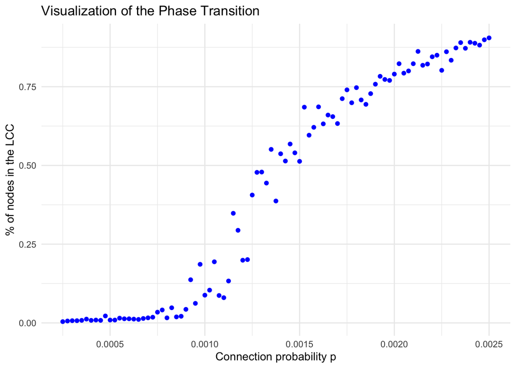

```r
# Vectors for probabilities and LCC sizes
probs <- seq(0.00025, 0.0025, by = 0.000025)
lcc_size <- numeric(length(probs))
number_of_nodes = 1000

# Compute LCC sizes for different probabilities
for (i in seq_along(probs)) {
  p <- probs[i]
  G <- erdos.renyi.game(n = number_of_nodes, p = p, directed = FALSE)

  # Get the size of the largest connected component
  size_of_components <- components(G)$csize
  lcc_size[i] <- max(size_of_components)
}

# Create a dataframe for plotting
df <- data.frame(probability = probs, LCC_fraction = lcc_size / number_of_nodes)

# Plot
ggplot(df, aes(x = probability, y = LCC_fraction)) +
  geom_point(color = "blue") +
  labs(title = "Visualization of the Phase Transition",
       x = "Connection probability p",
       y = "% of nodes in the LCC") +
  theme_minimal()
```

In a graph $G_{n, p}$, the presence of a giant component (a component containing more than 50% of all nodes of the whole graph) is dependent on the value of p. If we had no pre-knowledge about the science of networks, our expectation for the plot above would probably have been to see a linear relationship. This, however, is not what we observe: instead of a linear relationship we find that there is a special value of p for which we observe a phase transition: If p is lower than that value there is no giant component; if it is higher we find most nodes belonging to the giant connected component.

In the ER-model, the threshold for all nodes to be connected is $t(n) = log(n) / n$. This nonlinearity is sometimes called a “phase transition”.